# FP-Growth

Syahron Fitrahjon-Institut Teknologi Statistika dan Bisnis Muhammadiyah

2023-01-15

# PENGERTIAN

FP-Growth adalah algoritma pencarian frequent itemsets yang didapat dari FP-tree (Rama Novta Miraldi, 2014). Algoritma FP-Growth merupakan pengembangan dari algoritma Apriori. Sehingga kekurangan dari algoritma Apriori diperbaiki di algoritma FP-Growth. Algoritma ini menenfukan frequent itemset yang berakhkan suffix tertentu dengan menggunakan metode devide and conquer untuk memecah problem menjadi subproblem yang lebih kecil (Han, Kamber, & Pei, Data Mining : Concepts and Techniques, 201I). Jadi dapat disimpulkan bahwa FP-Growth adalah salah satu algoritma yang digunakan untuk mencari himpunan data yang sering muncul dari sekumpulan data, dengan menggunakan cara pembangktan stuktur data Tree.

# TUJUAN PEMBELAJARAN

## Analisis Afinitas

Analisis afinitas adalah studi tentang atribut atau karakteristik yang “berjalan bersama”. Metode untuk analisis afinitas, juga dikenal sebagai analisis keranjang pasar, berusaha mengungkap asosiasi di antara atribut-atribut ini; yaitu, ia berusaha mengungkap aturan untuk mengukur hubungan antara dua atau lebih atribut. Aturan asosiasi mengambil bentuk “Jika anteseden, maka konsekuensinya”, bersama dengan ukuran dukungan dan kepercayaan yang terkait dengan aturan tersebut.

## Apriori dalam R Studio

Apriori() menghasilkan seperangkat aturan yang paling relevan dari data transaksi tertentu. Ini juga menunjukkan dukungan, kepercayaan diri, dan pencabutan aturan tersebut. Ketiga ukuran ini dapat digunakan untuk memutuskan kekuatan relatif aturan. Jadi apa arti istilah-istilah ini?

> Support $=\frac{\text { Number of transactions with both } A \text { and } B}{\text { Total number of transactions }}=P(A \cap B)$

> Confidence $=\frac{\text { Number of transactions with both A and } B}{\text { Total number of transactions with } A}=\frac{P(A \cap B)}{P(A)}$

> ExpectedCon fidence $=\frac{\text { Number of transactions with } B}{\text { Total number of transactions }}=P(B)$

> Lift $=\frac{\text { Confidence }}{\text { Expected Confidence }}=\frac{P(A \cap B)}{P(A) \cdot P(B)}$

# TAHAPAN

## Algoritma dan Paket

```r
library(Matrix)
library(arules)
```

```r
library(arulesViz)
library(grid)
data("Groceries")
class(Groceries)
```

```
## [1] "transactions"
## attr(,"package")
## [1] "arules"
```

```r
inspect(head(Groceries, 3))
```

```
##     items
## [1] {citrus fruit,
##      semi-finished bread,
##      margarine,
##      ready soups}
## [2] {tropical fruit,
##      yogurt,
##      coffee}
## [3] {whole milk}
```

## Produk Paling Sering

```r
frequentItems <- eclat (Groceries, parameter = list(supp = 0.07, maxlen = 15)) #Menghitung dukungan untuk item yang sering
```

```
## Eclat
##
## parameter specification:
##  tidLists support minlen maxlen            target  ext
##     FALSE    0.07      1     15 frequent itemsets TRUE
##
## algorithmic control:
##  sparse sort verbose
##       7   -2    TRUE
##
## Absolute minimum support count: 688
##
## create itemset ...
## set transactions ...[169 item(s), 9835 transaction(s)] done [0.01s].
## sorting and recoding items ... [18 item(s)] done [0.00s].
## creating sparse bit matrix ... [18 row(s), 9835 column(s)] done [0.00s].
## writing  ... [19 set(s)] done [0.00s].
## Creating S4 object  ... done [0.00s].
```

```r
inspect(frequentItems)
```

```
##      items                          support    count
## [1]  {other vegetables, whole milk} 0.07483477  736
## [2]  {whole milk}                   0.25551601 2513
## [3]  {other vegetables}             0.19349263 1903
## [4]  {rolls/buns}                   0.18393493 1809
## [5]  {yogurt}                       0.13950178 1372
## [6]  {soda}                         0.17437722 1715
## [7]  {root vegetables}              0.10899847 1072
## [8]  {tropical fruit}               0.10493137 1032
## [9]  {bottled water}                0.11052364 1087
## [10] {sausage}                      0.09395018  924
## [11] {shopping bags}                0.09852567  969
## [12] {citrus fruit}                 0.08276563  814
## [13] {pastry}                       0.08896797  875
## [14] {pip fruit}                    0.07564820  744
## [15] {whipped/sour cream}           0.07168277  705
## [16] {fruit/vegetable juice}        0.07229283  711
## [17] {newspapers}                   0.07981698  785
## [18] {bottled beer}                 0.08052872  792
## [19] {canned beer}                  0.07768175  764
```

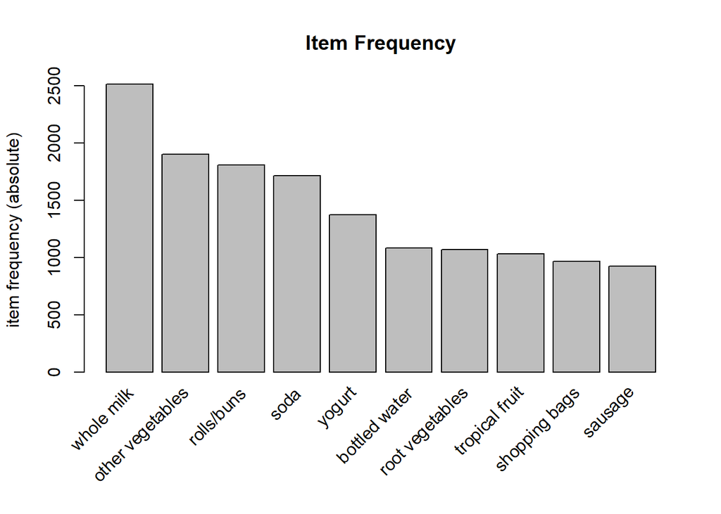

```r
itemFrequencyPlot(Groceries, topN=10, type="absolute", main="Item Frequency")
```